# MKTing_Analytics_V12

### **Libraries**

```python
import warnings
warnings.filterwarnings("ignore")

import pandas as pd
import numpy as np
import mlxtend.frequent_patterns as mlx

import seaborn as sns
sns.set_context("notebook")
sns.set_style('whitegrid', rc={'axes.edgecolor':'white', 'grid.linestyle':'dashed'})
import matplotlib.pyplot as plt
```

### **Data Import**

**Customers_Data.csv -** This file contains the customer’s demographics

- *CustomerID* - Customer Unique ID
- *Gender* - Gender of customer
- *Location* - Location of Customer
- *Tenure_Months* - Tenure in Months

```python
import_customer_info = pd.read_csv('https://raw.githubusercontent.com/lavender-brown/E-Commerce-Marketing-Insights/main/CustomersData.csv')

import_customer_info
```

|  | CustomerID | Gender | Location | Tenure_Months |
| --- | --- | --- | --- | --- |
| 0 | 17850 | M | Chicago | 12 |
| 1 | 13047 | M | California | 43 |
| 2 | 12583 | M | Chicago | 33 |
| 3 | 13748 | F | California | 30 |
| 4 | 15100 | M | California | 49 |
| ... | ... | ... | ... | ... |
| 1463 | 14438 | F | New York | 41 |
| 1464 | 12956 | F | Chicago | 48 |
| 1465 | 15781 | M | New Jersey | 19 |
| 1466 | 14410 | F | New York | 45 |
| 1467 | 14600 | F | California | 7 |

1468 rows × 4 columns

**Online_Sales.csv -** This file contains actual order data (point of Sales data) at the transaction level with the below variables

- *CustomerID* - Customer unique ID
- *Transaction_ID* - Transaction Unique ID
- *Transaction_Date* - Date of Transaction
- *Product_SKU* - Unique ID for the product
- *Product_Description* - Product Description
- *Product_Cateogry* - Product Category
- *Quantity* - Number of items ordered
- *Avg_Price* - Price per one quantity
- *Delivery_Charges* - Charges for delivery
- *Coupon_Status* - Any discount coupon applied

```python
import_online_sales = pd.read_csv('https://raw.githubusercontent.com/lavender-brown/E-Commerce-Marketing-Insights/main/Online_Sales.csv')

import_online_sales
```

|  | CustomerID | Transaction_ID | Transaction_Date | Product_SKU | Product_Description | Product_Category | Quantity | Avg_Price | Delivery_Charges | Coupon_Status |
| --- | --- | --- | --- | --- | --- | --- | --- | --- | --- | --- |
| 0 | 17850 | 16679 | 1/1/2019 | GGOENEBJ079499 | Nest Learning Thermostat 3rd Gen-USA - Stainle... | Nest-USA | 1 | 153.71 | 6.50 | Used |
| 1 | 17850 | 16680 | 1/1/2019 | GGOENEBJ079499 | Nest Learning Thermostat 3rd Gen-USA - Stainle... | Nest-USA | 1 | 153.71 | 6.50 | Used |
| 2 | 17850 | 16681 | 1/1/2019 | GGOEGFKQ020399 | Google Laptop and Cell Phone Stickers | Office | 1 | 2.05 | 6.50 | Used |
| 3 | 17850 | 16682 | 1/1/2019 | GGOEGAAB010516 | Google Men's 100% Cotton Short Sleeve Hero Tee... | Apparel | 5 | 17.53 | 6.50 | Not Used |
| 4 | 17850 | 16682 | 1/1/2019 | GGOEGBJL013999 | Google Canvas Tote Natural/Navy | Bags | 1 | 16.50 | 6.50 | Used |
| ... | ... | ... | ... | ... | ... | ... | ... | ... | ... | ... |
| 52919 | 14410 | 48493 | 12/31/2019 | GGOENEBB078899 | Nest Cam Indoor Security Camera - USA | Nest-USA | 1 | 121.30 | 6.50 | Clicked |
| 52920 | 14410 | 48494 | 12/31/2019 | GGOEGAEB091117 | Google Zip Hoodie Black | Apparel | 1 | 48.92 | 6.50 | Used |
| 52921 | 14410 | 48495 | 12/31/2019 | GGOENEBQ084699 | Nest Learning Thermostat 3rd Gen-USA - White | Nest-USA | 1 | 151.88 | 6.50 | Used |
| 52922 | 14600 | 48496 | 12/31/2019 | GGOENEBQ079199 | Nest Protect Smoke + CO White Wired Alarm-USA | Nest-USA | 5 | 80.52 | 6.50 | Clicked |
| 52923 | 14600 | 48497 | 12/31/2019 | GGOENEBQ079099 | Nest Protect Smoke + CO White Battery Alarm-USA | Nest-USA | 4 | 80.52 | 19.99 | Clicked |

52924 rows × 10 columns

**Discount_Coupon.csv -** Discount coupons have were given for different categories in different months

- *Month* - Discount coupon applied in that month
- *Product_Category* - Product category
- *Coupon_Code* - Coupon Code for given Category and given month
- *Discount_pct* - Discount Percentage for a given coupon

```python
import_discount_coupon = pd.read_csv('https://raw.githubusercontent.com/lavender-brown/E-Commerce-Marketing-Insights/main/Discount_Coupon.csv')

import_discount_coupon
```

|  | Month | Product_Category | Coupon_Code | Discount_pct |
| --- | --- | --- | --- | --- |
| 0 | Jan | Apparel | SALE10 | 10 |
| 1 | Feb | Apparel | SALE20 | 20 |
| 2 | Mar | Apparel | SALE30 | 30 |
| 3 | Jan | Nest-USA | ELEC10 | 10 |
| 4 | Feb | Nest-USA | ELEC20 | 20 |
| ... | ... | ... | ... | ... |
| 199 | Nov | Notebooks & Journals | NJ20 | 20 |
| 200 | Dec | Notebooks & Journals | NJ30 | 30 |
| 201 | Oct | Android | AND10 | 10 |
| 202 | Nov | Android | AND20 | 20 |
| 203 | Dec | Android | AND30 | 30 |

204 rows × 4 columns

**Marketing_Spend.csv -** Marketing spend on both offline & online channels on day wise

- *Date* - Date
- *Offline_Spend* - Marketing spends on offline channels like TV, Radio, Newspapers, hoardings, etc.
- *Online_Spend* - Marketing spend on online channels like Google keywords, Facebook, etc.

```python
import_mkting_expenses = pd.read_csv('https://raw.githubusercontent.com/lavender-brown/E-Commerce-Marketing-Insights/main/Marketing_Spend.csv')

import_mkting_expenses
```

|  | Date | Offline_Spend | Online_Spend |
| --- | --- | --- | --- |
| 0 | 1/1/2019 | 4500 | 2424.50 |
| 1 | 1/2/2019 | 4500 | 3480.36 |
| 2 | 1/3/2019 | 4500 | 1576.38 |
| 3 | 1/4/2019 | 4500 | 2928.55 |
| 4 | 1/5/2019 | 4500 | 4055.30 |
| ... | ... | ... | ... |
| 360 | 12/27/2019 | 4000 | 3396.87 |
| 361 | 12/28/2019 | 4000 | 3246.84 |
| 362 | 12/29/2019 | 4000 | 2546.58 |
| 363 | 12/30/2019 | 4000 | 674.31 |
| 364 | 12/31/2019 | 4000 | 2058.75 |

365 rows × 3 columns

**Tax_Amount.csv -** GST Details for given category

- *Product_Category* - Product Category
- *GST* - Percentage of GST

```python
import_tax_amount = pd.read_csv('https://raw.githubusercontent.com/lavender-brown/E-Commerce-Marketing-Insights/main/Tax_amount.csv')

import_tax_amount
```

|  | Product_Category | GST |
| --- | --- | --- |
| 0 | Nest-USA | 10% |
| 1 | Office | 10% |
| 2 | Apparel | 18% |
| 3 | Bags | 18% |
| 4 | Drinkware | 18% |
| 5 | Lifestyle | 18% |
| 6 | Notebooks & Journals | 5% |
| 7 | Headgear | 5% |
| 8 | Waze | 18% |
| 9 | Fun | 18% |
| 10 | Nest-Canada | 10% |
| 11 | Backpacks | 10% |
| 12 | Google | 10% |
| 13 | Bottles | 5% |
| 14 | Gift Cards | 5% |
| 15 | More Bags | 18% |
| 16 | Housewares | 12% |
| 17 | Android | 10% |
| 18 | Accessories | 10% |
| 19 | Nest | 5% |

### **Data Exploration**

```python
temp_dfs_list = [import_customer_info, import_online_sales, import_discount_coupon, import_mkting_expenses, import_tax_amount]

for _ in temp_dfs_list:
    #print(_.isnull().sum())
    #print(_.dtypes)
    print(_.shape)
```

```
(1468, 4)
(52924, 10)
(204, 4)
(365, 3)
(20, 2)
```

### **Data Transformation**

*Changes must be made under original imports to ensure data is available for further use*

```python
### Calculating the Gross Revenue per Order
import_online_sales['Gross_Order_Revenue'] = import_online_sales['Avg_Price'] * import_online_sales['Quantity']

### Turning discount coupon values into percentage
import_discount_coupon['Real_Discount_pct'] = import_discount_coupon['Discount_pct']/100

### Setting a multiplier for used coupons
import_online_sales['Coupon_Mult'] = np.where(import_online_sales['Coupon_Status'] == 'Used', 1, 0)

### Setting merge conditions, coupons per category and month number
# Turning 'Transaction_Date' type from object to datetime
import_online_sales['Transaction_Date'] = pd.to_datetime(import_online_sales['Transaction_Date'], format='%m/%d/%Y')

# Adding month number to 'import_online_sales' DF
import_online_sales['Transaction_Month'] = import_online_sales['Transaction_Date'].dt.month

# Adding month number to 'import_discount_coupon' DF
temp_month_dict = {'Jan':'01/01/19',
                   'Feb':'01/02/19',
                   'Mar':'01/03/19',
                   'Apr':'01/04/19',
                   'May':'01/05/19',
                   'Jun':'01/06/19',
                   'Jul':'01/07/19',
                   'Aug':'01/08/19',
                   'Sep':'01/09/19',
                   'Oct':'01/10/19',
                   'Nov':'01/11/19',
                   'Dec':'01/12/19'}

import_discount_coupon['Date'] = import_discount_coupon['Month']
import_discount_coupon['Date'] = import_discount_coupon['Date'].map(temp_month_dict)
import_discount_coupon['Month_Number'] = pd.to_datetime(import_discount_coupon['Date'], format='%d/%m/%y').dt.month

### To calculate revenue, coupons must be correct for all items
# Understanding which 'Product_Category's differ between DFs
set(import_discount_coupon['Product_Category']).symmetric_difference(set(import_online_sales['Product_Category']))

# Searching for asymmetries inside DFs
set(import_online_sales['Product_Category']).intersection(set(import_discount_coupon['Product_Category']).symmetric_difference(set(import_online_sales['Product_Category'])))

set(import_discount_coupon['Product_Category']).intersection(set(import_discount_coupon['Product_Category']).symmetric_difference(set(import_online_sales['Product_Category'])))

# Replacing 'Notebook' value with 'Notebooks & Journals' in Coupons DF 'Product_Category'
import_discount_coupon['Product_Category'] = np.where(import_discount_coupon['Product_Category']=='Notebooks', 'Notebooks & Journals', import_discount_coupon['Product_Category'])

# Replacing ['Backpacks', 'Fun', 'Google', 'More Bags'] values with ['Bags', 'Accessories', 'Drinkware', 'Bags'] in Sales DF 'Product_Category'
for x, y in zip(['Backpacks', 'Fun', 'Google', 'More Bags'], ['Bags', 'Accessories', 'Drinkware', 'Bags']):
    import_online_sales['Product_Category'] = np.where(import_online_sales['Product_Category']==x, y, import_online_sales['Product_Category'])

# Replacing {'Backpacks', 'Fun', 'Google', 'More Bags'} values with with ['Bags', 'Accessories', 'Drinkware', 'Bags'] in Taxes DF 'Product_Category'
for x, y in zip(['Backpacks', 'Fun', 'Google', 'More Bags'], ['Bags', 'Accessories', 'Drinkware', 'Bags']):
    import_tax_amount['Product_Category'] = np.where(import_tax_amount['Product_Category']==x, y, import_tax_amount['Product_Category'])

# Removing duplicated coupons for same category in same month
import_discount_coupon = import_discount_coupon.drop_duplicates(subset=['Month', 'Product_Category', 'Discount_pct'], keep='first')

# Transforming Tax rates into numeric types
import_tax_amount['Tax_Rate'] = pd.to_numeric(import_tax_amount['GST'].str.replace('%', '')) / 100

# Removing duplicated Tax Rates [Accessories 10%, Bags 10%, Bags 18%, Drinkware 10%]
import_tax_amount = import_tax_amount[~((import_tax_amount['Product_Category'] == 'Accessories') & (import_tax_amount['GST'] == '10%'))]
import_tax_amount = import_tax_amount[~((import_tax_amount['Product_Category'] == 'Bags') & (import_tax_amount['GST'] == '10%'))]
import_tax_amount = import_tax_amount[~((import_tax_amount['Product_Category'] == 'Drinkware') & (import_tax_amount['GST'] == '10%'))]
import_tax_amount = import_tax_amount.drop_duplicates()

### MARKETING INSIGHTS
# Transforming Date column into actual datetime type
import_mkting_expenses['Date'] = pd.to_datetime(import_mkting_expenses['Date'], format='%m/%d/%Y')

# Adding a 'Month_Number' column to the data import
import_mkting_expenses['Month_Number'] = import_mkting_expenses['Date'].dt.month

# Adding a 'Total_MKTing_Expense' Column to data import
import_mkting_expenses['Total_MKTing_Expense'] = import_mkting_expenses['Online_Spend'] + import_mkting_expenses['Offline_Spend']

# Turning import_online_sales 'CustomerID' into str type instead of float type
import_online_sales['CustomerID'] = import_online_sales['CustomerID'].astype('object')

# Turning import_customer_info 'CustomerID' into str type instead of float type
import_customer_info['CustomerID'] = import_customer_info['CustomerID'].astype('object')
```

## **Business Analytics**

### Descriptive Analytics

*Section I*

1. Totals Table (gross income, loss in coupons, taxes paid, net income, products sold, orders, marketing expense, customers)
2. Evolution of revenue / marketing expenses / coupon expenses / net income
3. Sales distribution
4. Orders per customer distribution

*Section II*

5. Which product categories represent the most / least net income?
6. Understand categories quantity-revenue relationships

*Section III*

7. Best / worst selling products based on net income and demand
8. Build a pareto to understand impact of best products by net income
9. Which products are bought mostly with coupons?
10. Which were our most succcesful coupons?
11. Are there any products that sell significantly better with coupons?
12. Is there a clear relation between coupons-sales-revenue?

*Section IV*

13. Which location drives our revenue?
14. Which locations receive the most orders?
15. Evolution of Net Income per Location
16. Which products perform better by location?

*Section V*

17. Where do my customers live?
18. Who are our most loyal customers?
19. Who are our most profitable customers?
20. How many one-time-customers did we had?
21. How much did one-timers paid us?

#### *Descriptive Analytics: Section I*

1. Totals Table (gross income, loss in coupons, taxes paid, net income, products sold, orders, marketing expense, customers)
2. Evolution of revenue / marketing expenses / coupon expenses / net income
3. Sales distribution
4. Orders per customer distribution

```python
### 1. Totals Table (gross income, loss in coupons, taxes paid, net income, products sold, orders, marketing expense, customers)

# Adding coupons and taxes data to sales data
sales_w_coupons = pd.merge(left=import_online_sales,
                           right=import_discount_coupon[['Month_Number', 'Product_Category', 'Coupon_Code', 'Real_Discount_pct']],
                           left_on=['Transaction_Month', 'Product_Category'],
                           right_on=['Month_Number', 'Product_Category'],
                           how='left').drop(['Month_Number'], axis=1)

sales_w_taxes = pd.merge(left=sales_w_coupons,
                         right=import_tax_amount,
                         on='Product_Category',
                         how='left').drop('GST', axis=1)

sales_table = pd.merge(left=sales_w_taxes,
                       right=import_customer_info,
                       on='CustomerID',
                       how='left')

sales_table['Real_Order_Revenue'] = (sales_table['Gross_Order_Revenue'] * (1-(sales_table['Coupon_Mult']*
                                                                              sales_table['Real_Discount_pct'])))

sales_table['Real_Discount_Cash'] = sales_table['Gross_Order_Revenue'] - sales_table['Real_Order_Revenue']

sales_table['Transaction_Tax'] = sales_table['Real_Order_Revenue'] * sales_table['Tax_Rate']

sales_table['Net_Order_Income'] = sales_table['Real_Order_Revenue'] - sales_table['Transaction_Tax']

#Calculating totals
totals_dict = {}

totals_dict['Total_Gross_Income'] = round(import_online_sales['Gross_Order_Revenue'].sum(), 2)

totals_dict['Total_Cash_Lost_in_Coupons'] = round(sales_table['Real_Discount_Cash'].sum(), 2)

totals_dict['Total_Taxes_Paid'] = round(sales_table['Transaction_Tax'].sum(), 2)

totals_dict['Total_Orders_Net_Income'] = totals_dict['Total_Gross_Income'] - (totals_dict['Total_Cash_Lost_in_Coupons']
                                                                              + totals_dict['Total_Taxes_Paid'])

totals_dict['Total_Marketing_Expenses'] = import_mkting_expenses['Total_MKTing_Expense'].sum()

totals_dict['Company_Net_Income'] = totals_dict['Total_Gross_Income'] - (totals_dict['Total_Cash_Lost_in_Coupons'] +
                                                                 totals_dict['Total_Marketing_Expenses'] +
                                                                 totals_dict['Total_Taxes_Paid'])

totals_dict['Total_Products_Sold'] = sales_table['Quantity'].sum()

totals_dict['Total_Active_Customers'] = import_customer_info['CustomerID'].nunique()

totals_dict['Total_Orders'] = sales_table['Transaction_ID'].nunique()

totals_table = pd.DataFrame(totals_dict.items(), columns=['Concept', 'Value'])

totals_table['Pct_of_Gross_Income'] = round(totals_table['Value'] / totals_table.loc[totals_table['Concept']=='Total_Gross_Income', 'Value'].iloc[0], 3)*100

totals_table
```

|  | Concept | Value | Pct_of_Gross_Income |
| --- | --- | --- | --- |
| 0 | Total_Gross_Income | 4670794.62 | 100.0 |
| 1 | Total_Cash_Lost_in_Coupons | 312380.52 | 6.7 |
| 2 | Total_Taxes_Paid | 482406.57 | 10.3 |
| 3 | Total_Orders_Net_Income | 3876007.53 | 83.0 |
| 4 | Total_Marketing_Expenses | 1733546.47 | 37.1 |
| 5 | Company_Net_Income | 2142461.06 | 45.9 |
| 6 | Total_Products_Sold | 238033.00 | 5.1 |
| 7 | Total_Active_Customers | 1468.00 | 0.0 |
| 8 | Total_Orders | 25061.00 | 0.5 |

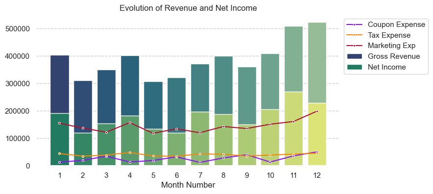

```python
### 2. Evolution of revenue / marketing expenses / coupon expenses / net income
revenue_w_coupn = pd.merge(left=sales_table.groupby('Transaction_Month')['Gross_Order_Revenue'].sum().reset_index(),
                           right=sales_table.groupby('Transaction_Month')['Real_Discount_Cash'].sum().reset_index(),
                           on='Transaction_Month',
                           how='inner')

revenue_w_taxes = pd.merge(left=revenue_w_coupn,
                           right=sales_table.groupby('Transaction_Month')['Transaction_Tax'].sum().reset_index(),
                           on='Transaction_Month',
                           how='inner')

revenue_w_mktin = pd.merge(left=revenue_w_taxes,
                           right=import_mkting_expenses.groupby(by='Month_Number')['Total_MKTing_Expense']
                                                                                  .sum()
                                                                                  .reset_index(),
                           left_on='Transaction_Month',
                           right_on='Month_Number',
                           how='inner').drop('Month_Number', axis=1)

revenue_w_mktin['Net_Income'] = revenue_w_mktin['Gross_Order_Revenue'] - (revenue_w_mktin['Real_Discount_Cash']
                                                                          + revenue_w_mktin['Transaction_Tax']
                                                                          + revenue_w_mktin['Total_MKTing_Expense'])

plt.figure(figsize=(8,4))

sns.barplot(data=revenue_w_mktin, x='Transaction_Month', y='Gross_Order_Revenue',
            palette='crest_r', label='Gross Revenue')

sns.barplot(data=revenue_w_mktin, x='Transaction_Month', y='Net_Income',
            palette='summer', label='Net Income')

sns.lineplot(data=revenue_w_mktin, x=revenue_w_mktin.index, y='Real_Discount_Cash',
             marker='o', markersize=3, color='#8E13F2', label='Coupon Expense')

sns.lineplot(data=revenue_w_mktin, x=revenue_w_mktin.index, y='Transaction_Tax',
             marker='o', markersize=3, color='#F1880E', label='Tax Expense')

sns.lineplot(data=revenue_w_mktin, x=revenue_w_mktin.index, y='Total_MKTing_Expense',
             marker='o', markersize=3, color='#AA1234', label='Marketing Exp')

plt.title('Evolution of Revenue and Net Income')
plt.xlabel('Month Number')
plt.ylabel('')
plt.ylim(0,550*1000)
plt.legend(bbox_to_anchor=(1,1))
plt.show()
```

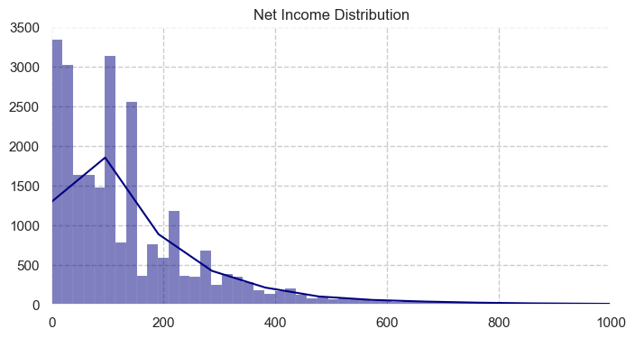

```python
### 3. Sales distribution
plt.figure(figsize=(8,4))
sns.histplot(data=sales_table.groupby(by='Transaction_ID')['Net_Order_Income']
                                                            .sum()
                                                            .reset_index(),
             x='Net_Order_Income', color='navy', kde=True, bins=1000)
plt.title('Net Income Distribution')
plt.xlabel('')
plt.xlim(0,1000)
plt.ylabel('')
plt.show()
```

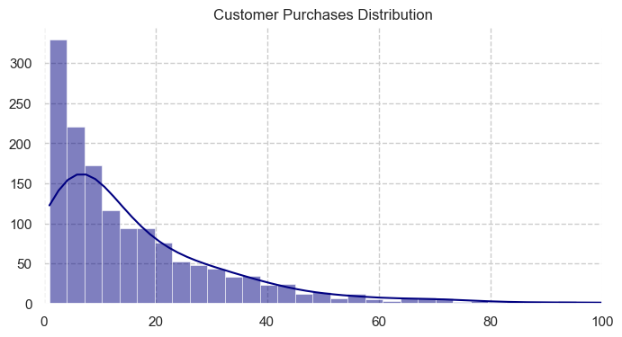

```python
### 4. Orders per customer distribution
plt.figure(figsize=(8,4))
sns.histplot(data=sales_table.groupby('CustomerID')['Transaction_ID']
                                                    .nunique()
                                                    .reset_index()
                                                    .sort_values(by='Transaction_ID',
                                                                 ascending=False),
             x='Transaction_ID', kde=True, color='navy')
plt.title('Customer Purchases Distribution')
plt.xlabel('')
plt.xlim(0,100)
plt.ylabel('')
plt.show()
```

#### *Descriptive Analytics: Section II*

5. Which product categories represent the most / least net income?
6. Understand categories quantity-revenue relationships

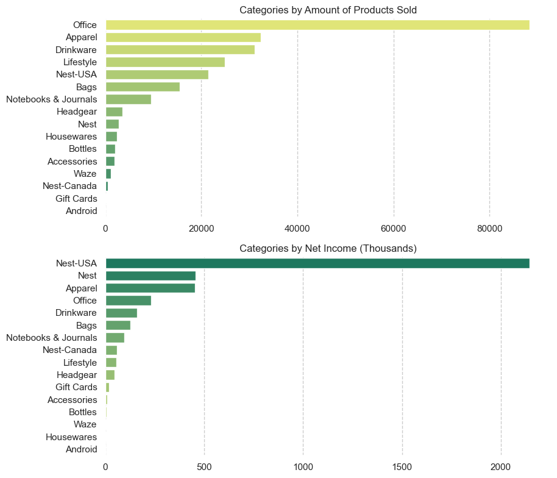

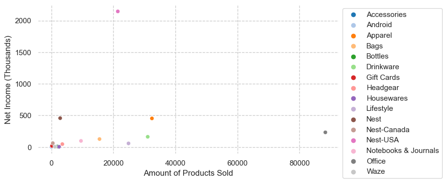

```python
### 5. Which product categories represent the most / least net income?
prod_catgs = sales_table.groupby(by='Product_Category')[['Net_Order_Income', 'Quantity']].sum().reset_index()
prod_catgs['Net_Order_Income'] = prod_catgs['Net_Order_Income'].div(1000)

fig, axes = plt.subplots(nrows=2, ncols=1, figsize=(9.3,8))

sns.barplot(data=prod_catgs.sort_values(by='Quantity', ascending=False),
            x='Quantity', y='Product_Category', palette='summer_r', ax=axes[0])

sns.barplot(data=prod_catgs.sort_values(by='Net_Order_Income', ascending=False),
            x='Net_Order_Income', y='Product_Category', palette='summer', ax=axes[1])

axes[0].set_title('Categories by Amount of Products Sold')
axes[0].set_xlabel('')
axes[0].set_ylabel('')

axes[1].set_title('Categories by Net Income (Thousands)')
axes[1].set_xlabel('')
axes[1].set_ylabel('')


plt.tight_layout()
plt.show()

### 6. Understand categories quantity-revenue relationships
plt.figure(figsize=(8,4))
sns.scatterplot(data=prod_catgs, x='Quantity', y='Net_Order_Income', hue='Product_Category', palette='tab20')
plt.xlabel('Amount of Products Sold')
plt.ylabel('Net Income (Thousands)')
plt.legend(bbox_to_anchor=(1,1))
plt.show()
```

#### *Descriptive Analytics: Section III*

7. Best / worst selling products based on net income and demand
8. Build a pareto to understand impact of best products by net income
9. Which products are bought mostly with coupons?
10. Which were our most succcesful coupons?
11. Are there any products that sell significantly better with coupons?
12. Is there a clear relation between coupons-sales-revenue?

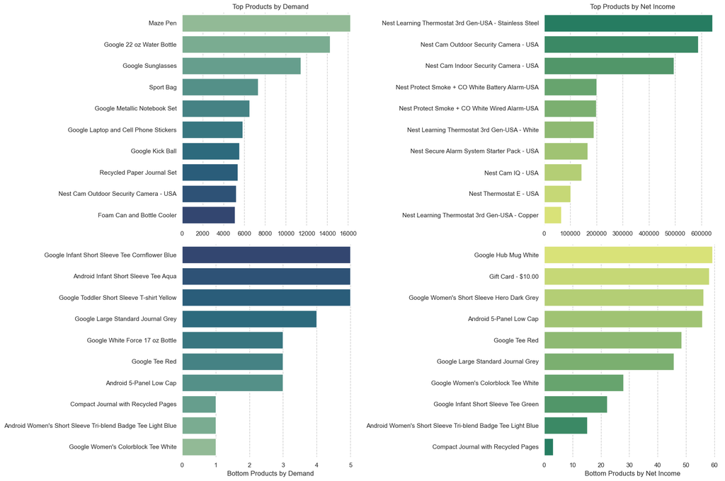

```python
### 7. Best / worst selling products based on net income and demand
fig, axes = plt.subplots(nrows=2, ncols=2, figsize=(18, 12))

sns.barplot(data=sales_table.groupby(by='Product_Description')['Quantity']
                                                                .sum()
                                                                .reset_index()
                                                                .sort_values(by='Quantity', ascending=False).head(10),
            x='Quantity', y='Product_Description',
            palette='crest', ax=axes[0,0])

sns.barplot(data=sales_table.groupby('Product_Description')['Real_Order_Revenue']
                                                            .sum()
                                                            .reset_index()
                                                            .sort_values(by='Real_Order_Revenue', ascending=False).head(10),
            x='Real_Order_Revenue', y='Product_Description',
            palette='summer', ax=axes[0,1])


sns.barplot(data=sales_table.groupby(by='Product_Description')['Quantity']
                                                                .sum()
                                                                .reset_index()
                                                                .sort_values(by='Quantity', ascending=False).tail(10),
            x='Quantity', y='Product_Description',
            palette='crest_r', ax=axes[1,0])

sns.barplot(data=sales_table.groupby('Product_Description')['Real_Order_Revenue']
                                                            .sum()
                                                            .reset_index()
                                                            .sort_values(by='Real_Order_Revenue', ascending=False).tail(10),
            x='Real_Order_Revenue', y='Product_Description',
            palette='summer_r', ax=axes[1,1])


axes[0, 0].set_title('Top Products by Demand')
axes[0, 1].set_title('Top Products by Net Income')

axes[0, 0].set_xlabel('')
axes[0, 1].set_xlabel('')
axes[1, 0].set_xlabel('Bottom Products by Demand')
axes[1, 1].set_xlabel('Bottom Products by Net Income')

axes[0, 0].set_ylabel('')
axes[0, 1].set_ylabel('')
axes[1, 0].set_ylabel('')
axes[1, 1].set_ylabel('')

plt.tight_layout()
plt.show()
```

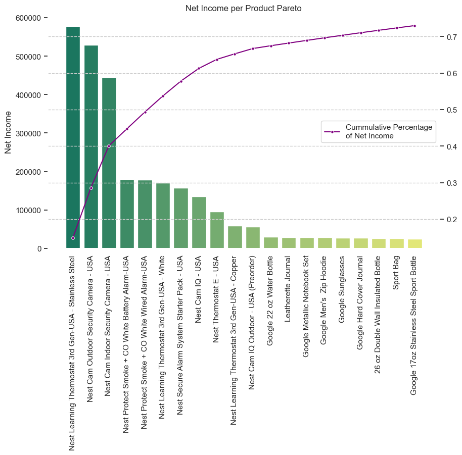

```python
### 8. Build a pareto to understand impact of best products by net income
best_selling_prods = sales_table.groupby(by='Product_Description')['Net_Order_Income'].sum().reset_index().sort_values(by='Net_Order_Income',
                                                                                                                       ascending=False)
best_selling_prods['Pct_of_Net_Income'] = round(best_selling_prods['Net_Order_Income'] /
                                                best_selling_prods['Net_Order_Income'].sum(),5)

best_selling_prods['Net_Income_Cummulative_Pct'] = best_selling_prods['Pct_of_Net_Income'].cumsum()

plt.figure(figsize=(10,6))
sns.barplot(data=best_selling_prods.head(20),
            x='Product_Description',
            y='Net_Order_Income',
            palette='summer')
plt.xlabel('')
plt.xticks(rotation=90)
plt.ylabel('Net Income')
plt.grid(False)

plt.twinx()

sns.lineplot(data=best_selling_prods.head(20),
             x='Product_Description',
             y='Net_Income_Cummulative_Pct',
             marker='o',
             markersize=4,
             color='purple',
             label='Cummulative Percentage\nof Net Income')
plt.title('Net Income per Product Pareto')
plt.ylabel('')
plt.legend(loc='center right')

plt.show()
```

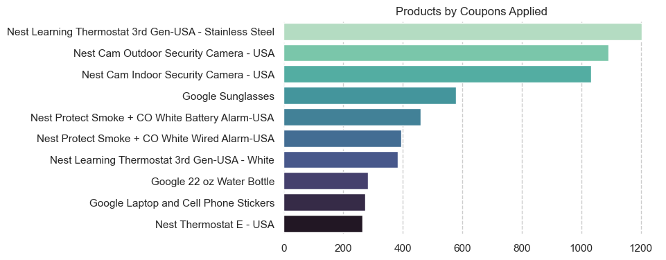

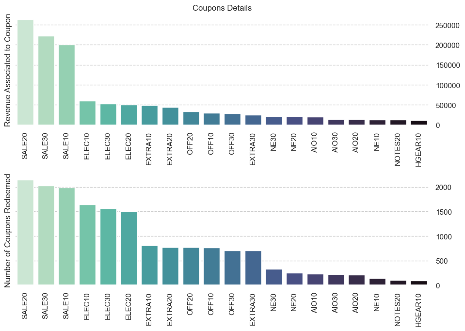

```python
### 9. Which products are bought mostly with coupons?
plt.figure(figsize=(7,4))
sns.barplot(data=sales_table[sales_table['Coupon_Mult']>0].groupby('Product_Description')['Coupon_Mult']
                                                                                            .sum()
                                                                                            .reset_index()
                                                                                            .sort_values(by='Coupon_Mult',
                                                                                                        ascending=False)
                                                                                            .head(10),
            x='Coupon_Mult', y='Product_Description',
            palette='mako_r')
plt.title('Products by Coupons Applied')
plt.xlabel('')
plt.ylabel('')
plt.show()

### 10. Which were our most succcesful coupons?
fig, axes = plt.subplots(nrows=2, ncols=1, figsize=(9.75,7))

sns.barplot(sales_table[sales_table['Coupon_Mult']>0].groupby(by='Coupon_Code')['Real_Order_Revenue']
                                                                                .sum()
                                                                                .reset_index()
                                                                                .sort_values(by='Real_Order_Revenue',
                                                                                             ascending=False)
                                                                                .head(20),
            x='Coupon_Code', y='Real_Order_Revenue',
            palette='mako_r', ax=axes[0])

sns.barplot(sales_table[sales_table['Coupon_Mult']>0].groupby(by='Coupon_Code')['Coupon_Mult']
                                                                                .sum()
                                                                                .reset_index()
                                                                                .sort_values(by='Coupon_Mult',
                                                                                             ascending=False)
                                                                                .head(20),
            x='Coupon_Code', y='Coupon_Mult',
            palette='mako_r', ax=axes[1])

axes[0].set_title('Coupons Details')
axes[0].set_xlabel('')
axes[0].set_ylabel('Revenue Associated to Coupon')
axes[0].set_xticklabels(axes[1].get_xticklabels(), rotation=90)
axes[0].tick_params(axis='y', labelleft=False, labelright=True)

axes[1].set_xlabel('')
axes[1].set_ylabel('Number of Coupons Redeemed')
axes[1].set_xticklabels(axes[1].get_xticklabels(), rotation=90)
axes[1].tick_params(axis='y', labelleft=False, labelright=True)

plt.tight_layout()
plt.show()
```

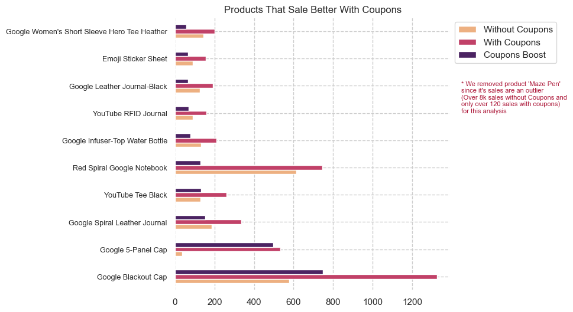

```python
### 11. Are there any products that sell significantly better with coupons?
prods_sales_w_coupons = pd.merge(left=sales_table[sales_table['Coupon_Mult']<1].groupby(by='Product_Description')['Quantity'].sum().reset_index(),
                                 right=sales_table[sales_table['Coupon_Mult']>0].groupby(by='Product_Description')['Quantity'].sum().reset_index(),
                                 on='Product_Description',
                                 how='left')

prods_sales_w_coupons = prods_sales_w_coupons.rename(columns={'Quantity_x':'Prods_Sold_without_Coupons', 'Quantity_y':'Prods_Sold_with_Coupons'})

prods_sales_w_coupons['Coupons_Sales_Boost'] = prods_sales_w_coupons['Prods_Sold_with_Coupons'] - prods_sales_w_coupons['Prods_Sold_without_Coupons']

prods_sales_w_coupons = prods_sales_w_coupons.sort_values(by='Coupons_Sales_Boost', ascending=False)

prods_sales_w_coupons.set_index('Product_Description').drop('Maze Pen', axis=0).head(10).plot(kind='barh',
                                                                                              figsize=(6,6),
                                                                                              colormap='flare')
plt.title('Products That Sale Better With Coupons')
plt.xlabel('')
plt.ylabel('')
plt.yticks(fontsize=9)
plt.legend(bbox_to_anchor=(1,1), loc='upper left',
           labels=['Without Coupons', 'With Coupons', 'Coupons Boost'])

plt.text(1450, 6, "* We removed product 'Maze Pen'\nsince it's sales are an outlier\n(Over 8k sales without Coupons and\nonly over 120 sales with coupons)\nfor this analysis",
         fontsize=8, color='#AA1234', ha='left')
plt.show()
```

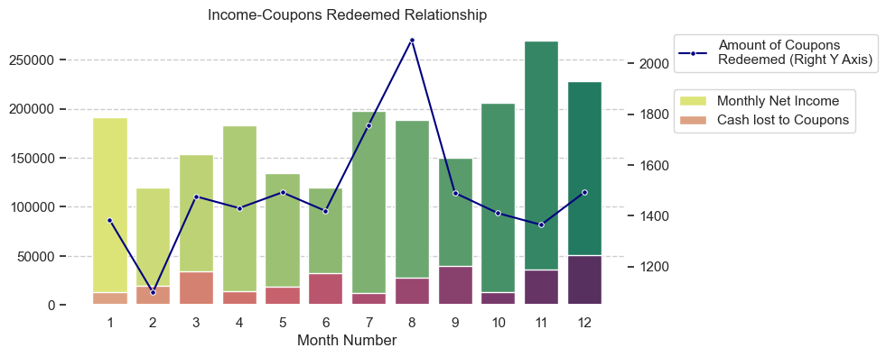

```python
### 12. Is there a clear relation between coupons-sales-revenue?
plt.figure(figsize=(8,4))
sns.barplot(data=pd.merge(left=sales_table.groupby('Transaction_Month')['Coupon_Mult'].sum(),
                          right=revenue_w_mktin[['Transaction_Month', 'Real_Discount_Cash', 'Net_Income']],
                          on='Transaction_Month',
                          how='inner'),
            x='Transaction_Month', y='Net_Income', palette='summer_r', label='Monthly Net Income')

sns.barplot(data=pd.merge(left=sales_table.groupby('Transaction_Month')['Coupon_Mult'].sum(),
                          right=revenue_w_mktin[['Transaction_Month', 'Real_Discount_Cash', 'Net_Income']],
                          on='Transaction_Month',
                          how='inner'),
            x='Transaction_Month', y='Real_Discount_Cash', palette='flare', label='Cash lost to Coupons')
plt.xlabel('Month Number')
plt.ylabel('')
plt.legend(bbox_to_anchor=(1.42,0.8))

plt.twinx()

sns.lineplot(data=pd.merge(left=sales_table.groupby('Transaction_Month')['Coupon_Mult'].sum(),
                           right=revenue_w_mktin[['Transaction_Month', 'Real_Discount_Cash', 'Net_Income']],
                           on='Transaction_Month',
                           how='inner'),
            x=sales_table.groupby('Transaction_Month')['Coupon_Mult']
                                                        .sum()
                                                        .reset_index()
                                                        .index,
            y='Coupon_Mult', color='navy', marker='o', markersize=4, label='Amount of Coupons\nRedeemed (Right Y Axis)')
plt.title('Income-Coupons Redeemed Relationship')
plt.ylabel('')
plt.grid(False)
plt.legend(bbox_to_anchor=(1.46,1))

plt.show()
```

#### *Descriptive Analytics: Section IV*

13. Which location drives our revenue?
14. Which locations receive the most orders?
15. Evolution of Net Income per Location
16. Which products perform better by location?

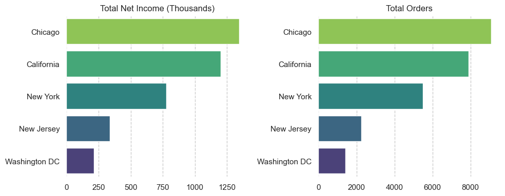

```python
### 13. Which location drives our revenue?
location_performance = pd.merge(left=sales_table.groupby('Location')['Transaction_ID'].nunique().reset_index().sort_values(by='Transaction_ID',
                                                                                                                           ascending=False),
                                right=sales_table.groupby('Location')['Net_Order_Income'].sum().reset_index().sort_values(by='Net_Order_Income',
                                                                                                                          ascending=False),
                                on='Location',
                                how='inner')

location_performance['Net_Order_Income'] = location_performance['Net_Order_Income'].div(1000)

### 14. Which locations receive the most orders?
fig, axes = plt.subplots(nrows=1, ncols=2, figsize=(10,4))
sns.barplot(data=location_performance, x='Net_Order_Income', y='Location', palette='viridis_r', ax=axes[0])

sns.barplot(data=location_performance, x='Transaction_ID', y='Location', palette='viridis_r', ax=axes[1])

axes[0].set_title('Total Net Income (Thousands)')
axes[0].set_xlabel('')
axes[0].set_ylabel('')

axes[1].set_title('Total Orders')
axes[1].set_xlabel('')
axes[1].set_ylabel('')

plt.tight_layout()
plt.show()
```

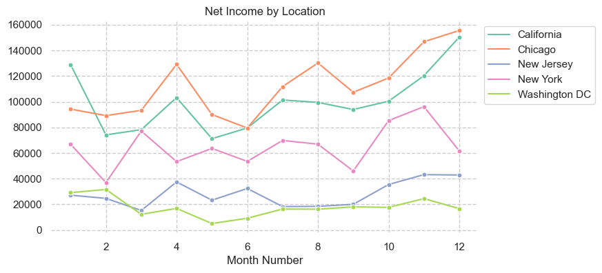

```python
### 15. Evolution of Net Income per Location
location_monthly_sales = pd.pivot_table(data=sales_table,
                                        values='Net_Order_Income', aggfunc='sum',
                                        index='Location', columns='Transaction_Month').T.reset_index().melt(id_vars='Transaction_Month')
plt.figure(figsize=(8,4))
sns.lineplot(data=location_monthly_sales,
             x='Transaction_Month', y='value',
             hue='Location', marker='o', markersize=5, palette='Set2')
plt.title('Net Income by Location')
plt.xlabel('Month Number')
plt.ylabel('')
plt.legend(bbox_to_anchor=(1,1))

plt.show()
```

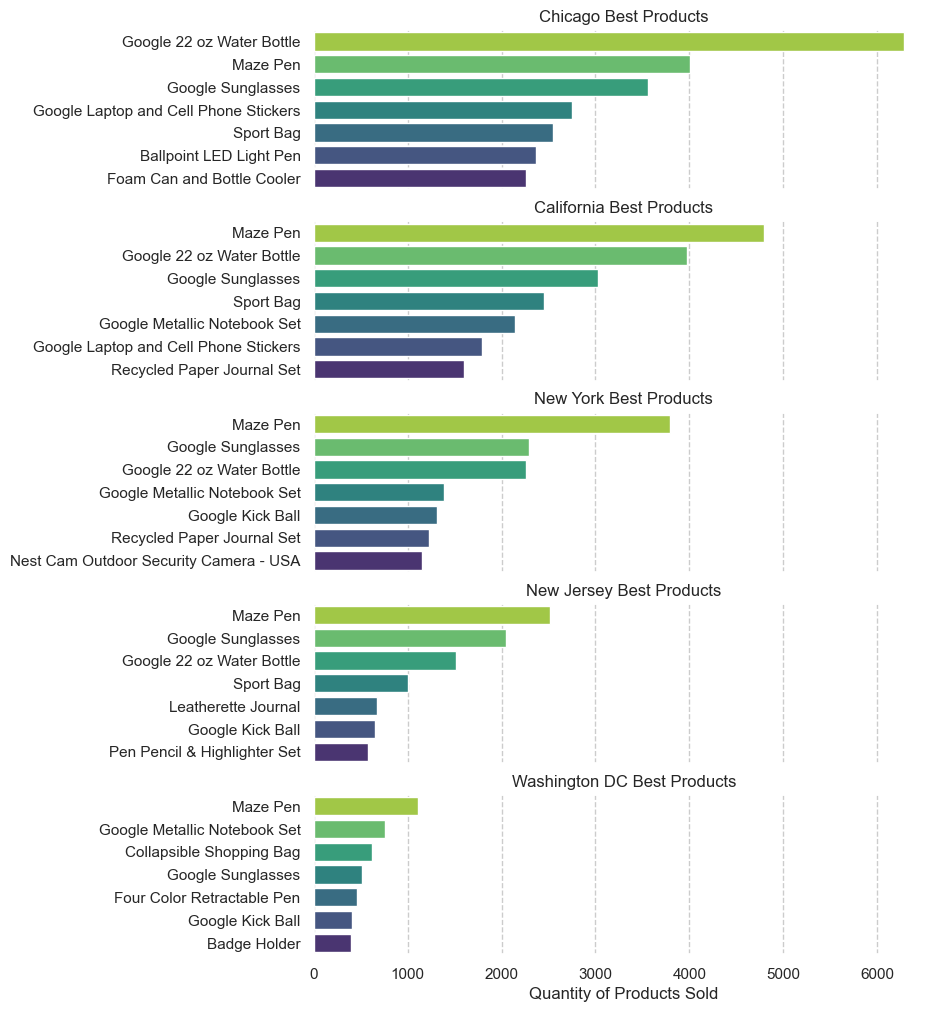

```python
### 16. Which products perform better by location?
prods_by_location = sales_table.groupby(['Location', 'Product_Description'])['Quantity'].sum().reset_index().sort_values(by='Quantity',
                                                                                                                         ascending=False)

fig, axes = plt.subplots(sales_table['Location'].nunique(), 1, figsize=(8, 12), sharex=True)

for i, l in enumerate(sales_table['Location'].unique()):
    sns.barplot(data=prods_by_location[prods_by_location['Location']==l].head(7),
                x='Quantity', y='Product_Description',
                palette='viridis_r', ax=axes[i])

    axes[i].set_title(f"{l} Best Products")
    axes[i].set_xlabel('')
    axes[i].set_ylabel('')

plt.xlabel('Quantity of Products Sold')
plt.show()
```

#### *Descriptive Analytics: Section V*

17. Where do my customers live?
18. Who are our most loyal customers?
19. Who are our most profitable customers?
20. How many one-time-customers did we had?
21. How much did one-timers paid us?

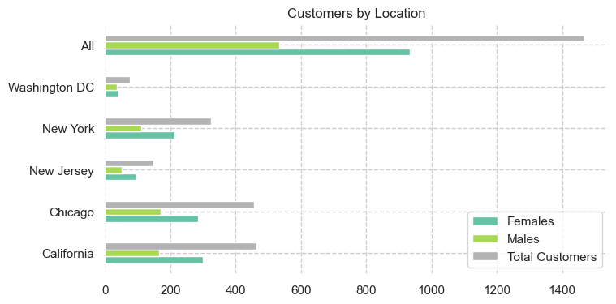

```python
### 17. Where do my customers live?
pd.pivot_table(data=import_customer_info,
               values='CustomerID', aggfunc='count',
               index='Location', columns='Gender', margins=True).plot(kind='barh',
                                                                      title='Customers by Location',
                                                                      ylabel=(''),
                                                                      figsize=(8,4),
                                                                      colormap='Set2')

plt.legend(loc='lower right',
           labels=['Females', 'Males', 'Total Customers'])
plt.show()
```

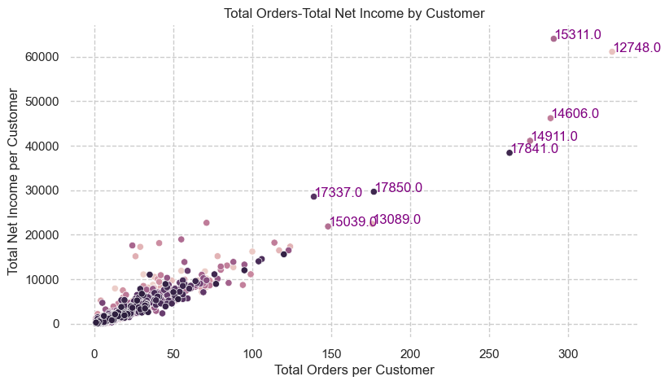

| CustomerID | Total Customer Income | Total Customer Orders |
| --- | --- | --- |
| 15311 | 64026.76 | 291 |
| 12748 | 61111.45 | 328 |
| 14606 | 46192.05 | 289 |
| 14911 | 41110.71 | 276 |
| 17841 | 38397.00 | 263 |
| 17850 | 29653.92 | 177 |
| 17337 | 28549.61 | 139 |
| 14667 | 22673.51 | 71 |
| 13089 | 22426.54 | 176 |
| 15039 | 21860.09 | 148 |
| 15194 | 18952.50 | 55 |
| 14646 | 18214.62 | 114 |
| 14180 | 18114.36 | 41 |
| 15351 | 17584.79 | 24 |
| 13174 | 17332.03 | 124 |

```python
### 18. Who are our most loyal customers?
customer_loyalty = pd.merge(left=sales_table.groupby(by='CustomerID')['Net_Order_Income'].sum().reset_index(),
                            right=sales_table.groupby(by='CustomerID')['Transaction_ID'].nunique().reset_index(),
                            on='CustomerID',
                            how='inner')

plt.figure(figsize=(9,5))
sns.scatterplot(data=customer_loyalty,
                x='Transaction_ID', y='Net_Order_Income',
                hue='CustomerID')

plt.title('Total Orders-Total Net Income by Customer')
plt.xlabel('Total Orders per Customer')
plt.ylabel('Total Net Income per Customer')
plt.legend().remove()

for idx, row in customer_loyalty.iterrows():
    if row['Transaction_ID'] > 120 and row['Net_Order_Income'] > 20000:
        plt.text(row['Transaction_ID'], row['Net_Order_Income'], row['CustomerID'], color='purple')

plt.show()

### 19. Who are our most profitable customers?
customer_loyalty['Net_Order_Income'] = round(customer_loyalty['Net_Order_Income'],2)

(customer_loyalty.sort_values(by='Net_Order_Income',ascending=False)
                 .set_index('CustomerID')
                 .rename(columns={'Net_Order_Income':'Total Customer Income',
                                  'Transaction_ID':'Total Customer Orders'})
                 .head(15))
```

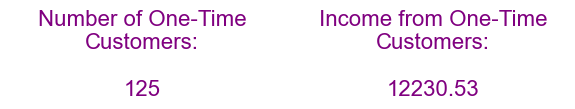

```python
### 21. How many one-time-customers did we had?
fig, axs = plt.subplots(1, 2, figsize=(6, 1))

axs[0].text(0.5, 0.5,
            f"Number of One-Time\nCustomers:\n\n{len(customer_loyalty[customer_loyalty['Transaction_ID']==1])}",
            ha='center', va='center', fontsize=16, color='purple')
axs[0].axis('off')

axs[1].text(0.5, 0.5,
            f"Income from One-Time\nCustomers:\n\n{customer_loyalty[customer_loyalty['Transaction_ID']==1]['Net_Order_Income'].sum()}",
            ha='center', va='center', fontsize=16, color='purple')
axs[1].axis('off')

plt.tight_layout()
plt.show()
```

### Business Required Analysis

1. Buying pattern of our best clients compared to our avg. clients and one-time consumers
2. Evolution of customers acquisition

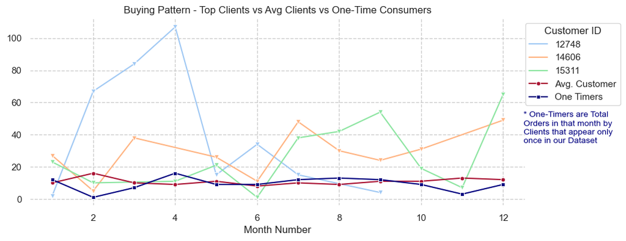

```python
### 1. Buying pattern of our best clients compared to our avg. clients and one-time consumers
top_three_clients = sales_table[sales_table['CustomerID']
                                              .isin(customer_loyalty
                                              .sort_values(by='Net_Order_Income', ascending=False)
                                              .head(3)['CustomerID']
                                              .unique())]

top_three_clients_monthly_orders = (top_three_clients
                                        .groupby(['CustomerID', 'Transaction_Month'])['Transaction_ID']
                                        .nunique()
                                        .reset_index())

all_clients_monthly_orders = (sales_table
      .groupby(['CustomerID', 'Transaction_Month'])['Transaction_ID']
      .nunique()
      .reset_index()
      .sort_values(by=['Transaction_Month', 'CustomerID']))

temp_month_avg_list = []

for i in list(all_clients_monthly_orders['Transaction_Month'].unique()):
    wy = round(all_clients_monthly_orders[all_clients_monthly_orders['Transaction_Month']==i]['Transaction_ID'].mean())
    temp_month_avg_list.append(['Avg_Customer', i, wy])

temp_month_avg_list = pd.DataFrame(temp_month_avg_list, columns=top_three_clients_monthly_orders.columns)

plt.figure(figsize=(10.5,4))

sns.lineplot(data=top_three_clients_monthly_orders,
             x='Transaction_Month', y='Transaction_ID',
             hue='CustomerID', palette='pastel', marker='v', markersize=6)

sns.lineplot(data=temp_month_avg_list,
             x='Transaction_Month', y='Transaction_ID',
             label='Avg. Customer', color='#AA1234', marker='o', markersize=5)

one_time_clients = sales_table[sales_table['CustomerID']
                               .isin(customer_loyalty[customer_loyalty['Transaction_ID']==1]['CustomerID'])]

one_time_clients_monthly = one_time_clients.groupby(by='Transaction_Month')['Transaction_ID'].nunique().reset_index()

sns.lineplot(data=one_time_clients_monthly,
             x='Transaction_Month', y='Transaction_ID',
             label='One Timers', color='navy', marker='s', markersize=5)

plt.title('Buying Pattern - Top Clients vs Avg Clients vs One-Time Consumers')
plt.xlabel('Month Number')
plt.ylabel('')
plt.legend(bbox_to_anchor=(1.2,1), title='Customer ID')
plt.text(12.5, 35, "* One-Timers are Total\nOrders in that month by\nClients that appear only\nonce in our Dataset",
         fontsize=10, color='navy', ha='left')
plt.show()
```

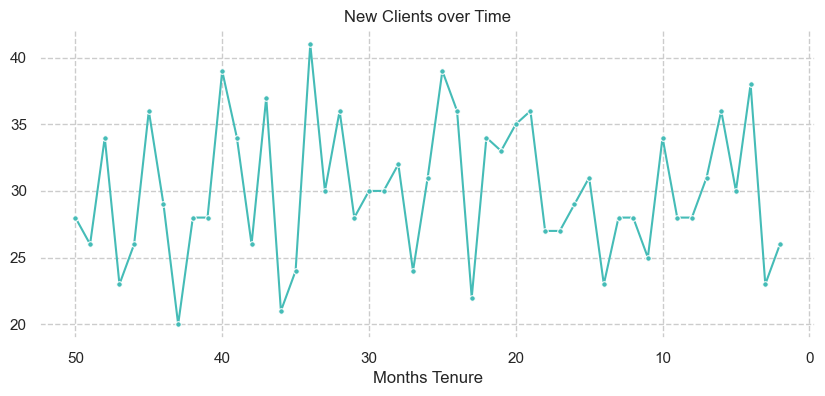

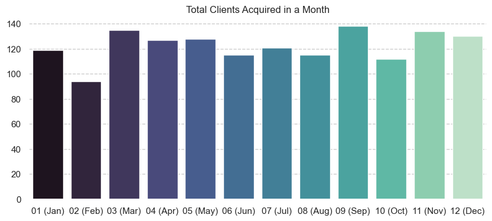

```python
### 2. Evolution of customers acquisition
qwer = (import_customer_info
        .groupby(by='Tenure_Months')['CustomerID']
        .nunique()
        .reset_index()
        .sort_values(by='Tenure_Months', ascending=False))

qwer['CumSum'] = qwer['CustomerID'].cumsum(axis=0)

qwer['RelChn'] = (qwer['CumSum']/qwer['CumSum'].shift(1))-1

plt.figure(figsize=(10,4))
sns.lineplot(data=qwer,
             x='Tenure_Months', y='CustomerID',
             color='#45bcb7', marker='o', markersize=4)
plt.gca().invert_xaxis()
plt.title('New Clients over Time')
plt.xlabel('Months Tenure')
plt.ylabel('')
plt.show()

# Assuming Data is collected on Jan 1st 2020, 1 Tenure Month means Client arrived in Dec, 2 in Nov, 3 in Oct, and so on
tenure_months = ['11 (Nov)','12 (Dec)','01 (Jan)','02 (Feb)','03 (Mar)','04 (Apr)','05 (May)','06 (Jun)','07 (Jul)','08 (Aug)',
                 '09 (Sep)','10 (Oct)','11 (Nov)','12 (Dec)','01 (Jan)','02 (Feb)','03 (Mar)','04 (Apr)','05 (May)','06 (Jun)',
                 '07 (Jul)','08 (Aug)','09 (Sep)','10 (Oct)','11 (Nov)','12 (Dec)','01 (Jan)','02 (Feb)','03 (Mar)','04 (Apr)',
                 '05 (May)','06 (Jun)','07 (Jul)','08 (Aug)','09 (Sep)','10 (Oct)','11 (Nov)','12 (Dec)','01 (Jan)','02 (Feb)',
                 '03 (Mar)','04 (Apr)','05 (May)','06 (Jun)','07 (Jul)','08 (Aug)','09 (Sep)','10 (Oct)','11 (Nov)']

qwer['Tenure_Month_Name'] = tenure_months

plt.figure(figsize=(10,4))
sns.barplot(data=qwer.groupby(by='Tenure_Month_Name')['CustomerID'].sum().reset_index().sort_values(by='Tenure_Month_Name'),
            x='Tenure_Month_Name', y='CustomerID',
            palette='mako')
plt.title('Total Clients Acquired in a Month')
plt.xlabel('')
plt.ylabel('')
plt.show()
```

### Business Recommendations

1. Identify Which products tend to sell together
2. Classify customers (Detail classification method)

**Recommendation 1. Identify Which products tend to sell together**

Definitions:

- *Antecedents:* Refers to the items that are already present in the basket before a purchase is made.
- *Consequents:* Consequents are the items that are likely to be added to the basket based on the presence of certain antecedents.
- *Antecedent Support:* Antecedent support is the proportion of transactions in the dataset that contain the antecedent item
- *Consequent Support:* Consequent support is the proportion of transactions in the dataset that contain the consequent item
- *Support:* Support is the proportion of transactions in the dataset that contain both the antecedent and consequent itemsets. It measures the frequency of co-occurrence of the items.
- *Confidence:* Confidence measures the probability that the consequent item or itemset will be purchased given that the antecedent item or itemset is already in the basket.
- *Lift:* Lift indicates the strength of the association between the antecedent and consequent. It measures the ratio of observed support to the expected support if the antecedent and consequent were independent. Lift greater than 1 indicates a positive association, while less than 1 indicates a negative association.
- *Leverage:* Leverage measures the difference between the observed frequency of antecedent and consequent co-occurrence and the frequency that would be expected if they were independent. It provides insights into whether the presence of the antecedent and consequent together is significantly higher or lower than what would be expected by chance.
- *Conviction:* Conviction measures the dependency of the consequent on the antecedent. It is calculated as the ratio of the expected frequency that the antecedent occurs without the consequent to the observed frequency of it occurring without the consequent. Conviction values greater than 1 indicate dependency.

**Recommendation:**

```python
### 1. Which products tend to sell together?
products_in_transaction = (sales_table.groupby(by=['Transaction_ID', 'Product_Description'])['Quantity']
                                      .sum()
                                      .unstack()
                                      .reset_index()
                                      .fillna(0)
                                      .set_index('Transaction_ID'))

products_in_transaction = products_in_transaction.map(lambda x: 1 if x > 0 else 0)

market_basket_analysis = mlx.apriori(df=products_in_transaction, min_support=0.005, use_colnames=True)

mlx.association_rules(df=market_basket_analysis, metric='support', min_threshold=0.005)
```

|  | antecedents | consequents | antecedent support | consequent support | support | confidence | lift | leverage | conviction | zhangs_metric |
| --- | --- | --- | --- | --- | --- | --- | --- | --- | --- | --- |
| 0 | (YouTube Custom Decals) | (Google Laptop and Cell Phone Stickers) | 0.016719 | 0.032162 | 0.005347 | 0.319809 | 9.943840 | 0.004809 | 1.422892 | 0.914729 |
| 1 | (Google Laptop and Cell Phone Stickers) | (YouTube Custom Decals) | 0.032162 | 0.016719 | 0.005347 | 0.166253 | 9.943840 | 0.004809 | 1.179352 | 0.929324 |
| 2 | (Nest Cam Indoor Security Camera - USA) | (Nest Cam Outdoor Security Camera - USA) | 0.128886 | 0.132796 | 0.027653 | 0.214551 | 1.615644 | 0.010537 | 1.104087 | 0.437430 |
| 3 | (Nest Cam Outdoor Security Camera - USA) | (Nest Cam Indoor Security Camera - USA) | 0.132796 | 0.128886 | 0.027653 | 0.208233 | 1.615644 | 0.010537 | 1.100216 | 0.439403 |
| 4 | (Nest Cam Indoor Security Camera - USA) | (Nest Learning Thermostat 3rd Gen-USA - Stainl... | 0.128886 | 0.140098 | 0.009098 | 0.070588 | 0.503848 | -0.008959 | 0.925211 | -0.530609 |
| 5 | (Nest Learning Thermostat 3rd Gen-USA - Stainl... | (Nest Cam Indoor Security Camera - USA) | 0.140098 | 0.128886 | 0.009098 | 0.064939 | 0.503848 | -0.008959 | 0.931612 | -0.533834 |
| 6 | (Nest Protect Smoke + CO White Battery Alarm-USA) | (Nest Cam Indoor Security Camera - USA) | 0.054307 | 0.128886 | 0.005985 | 0.110213 | 0.855124 | -0.001014 | 0.979015 | -0.151932 |
| 7 | (Nest Cam Indoor Security Camera - USA) | (Nest Protect Smoke + CO White Battery Alarm-USA) | 0.128886 | 0.054307 | 0.005985 | 0.046440 | 0.855124 | -0.001014 | 0.991749 | -0.162821 |
| 8 | (Nest Cam Outdoor Security Camera - USA) | (Nest Learning Thermostat 3rd Gen-USA - Stainl... | 0.132796 | 0.140098 | 0.012011 | 0.090445 | 0.645581 | -0.006594 | 0.945409 | -0.387653 |
| 9 | (Nest Learning Thermostat 3rd Gen-USA - Stainl... | (Nest Cam Outdoor Security Camera - USA) | 0.140098 | 0.132796 | 0.012011 | 0.085731 | 0.645581 | -0.006594 | 0.948521 | -0.389662 |
| 10 | (Nest Protect Smoke + CO White Battery Alarm-USA) | (Nest Cam Outdoor Security Camera - USA) | 0.054307 | 0.132796 | 0.007661 | 0.141073 | 1.062327 | 0.000449 | 1.009636 | 0.062039 |
| 11 | (Nest Cam Outdoor Security Camera - USA) | (Nest Protect Smoke + CO White Battery Alarm-USA) | 0.132796 | 0.054307 | 0.007661 | 0.057692 | 1.062327 | 0.000449 | 1.003592 | 0.067654 |
| 12 | (Nest Protect Smoke + CO White Battery Alarm-USA) | (Nest Learning Thermostat 3rd Gen-USA - Stainl... | 0.054307 | 0.140098 | 0.009018 | 0.166054 | 1.185272 | 0.001410 | 1.031125 | 0.165288 |
| 13 | (Nest Learning Thermostat 3rd Gen-USA - Stainl... | (Nest Protect Smoke + CO White Battery Alarm-USA) | 0.140098 | 0.054307 | 0.009018 | 0.064369 | 1.185272 | 0.001410 | 1.010754 | 0.181778 |
| 14 | (Nest Learning Thermostat 3rd Gen-USA - Stainl... | (Nest Protect Smoke + CO White Wired Alarm-USA) | 0.140098 | 0.042496 | 0.007222 | 0.051552 | 1.213100 | 0.001269 | 1.009548 | 0.204286 |
| 15 | (Nest Protect Smoke + CO White Wired Alarm-USA) | (Nest Learning Thermostat 3rd Gen-USA - Stainl... | 0.042496 | 0.140098 | 0.007222 | 0.169953 | 1.213100 | 0.001269 | 1.035968 | 0.183462 |

**Recommendation 2. Classify customers (Detail classification method)**

Classifying customers in *'Bronze'*, *'Silver'*, *'Platinum'* and *'Gold'* level

Classification is calulated the following way:

- Bronze Level: Ranging from 0% up-and-equal to 40%
- Silver Level: Ranging from 40% (Excluding 40%) up-and-equal to 70%
- Platinum Level: Ranging from 70% (Excluding 70%) up-and-equal to 90%
- Gold Level: Ranging from 90% (Excluding 90%) up-and-equal to 100%

**Recommendation:**

*Table below show GOLD level customers with NO Orders placed in the Last 90 Days*

*We recommend to approach these clients if possible*

```python
# 2. Classify customers (Detail classification method)
customer_loyalty['Client_Level'] = ((customer_loyalty['Net_Order_Income'].rank(pct=True)*0.80)
                                    + (customer_loyalty['Transaction_ID'].rank(pct=True)*0.20))

customer_loyalty['Level_Badge'] = pd.cut(customer_loyalty['Client_Level'],
                                         bins=[0.00, 0.40, 0.70, 0.90, 1.00],
                                         labels=['Bronze', 'Silver', 'Platinum', 'Gold'],
                                         right=True)

non_on_time_customers = customer_loyalty[~customer_loyalty['CustomerID']
                                         .isin(one_time_clients['CustomerID'].unique())]

customers_last_purchase_date = sales_table.groupby(by='CustomerID')['Transaction_Date'].max().reset_index()
customers_last_purchase_date['Current_Date'] = pd.to_datetime('2020-01-15', format='%Y-%m-%d')#pd.Timestamp.today().date())

customer_classification = pd.merge(left=non_on_time_customers,
                                   right=customers_last_purchase_date,
                                   on='CustomerID',
                                   how='left')

customer_classification['Days_Since_Last_Order'] = (customer_classification['Current_Date'] - customer_classification['Transaction_Date']).                       dt.days

customer_classification = customer_classification.drop('Client_Level', axis=1)

customer_classification = customer_classification.rename(columns={'Net_Order_Income':'Total_Client_Income',
                                                                  'Transaction_ID':'Total_Client_Orders',
                                                                  'Transaction_Date':'Last_Purchase_Date'})

(customer_classification.query("Level_Badge == 'Gold' and Days_Since_Last_Order  >= 90")
                        .sort_values(by='Days_Since_Last_Order', ascending=False)
                        .reset_index()
                        .head(10))
```

|  | index | CustomerID | Total_Client_Income | Total_Client_Orders | Level_Badge | Last_Purchase_Date | Current_Date | Days_Since_Last_Order |
| --- | --- | --- | --- | --- | --- | --- | --- | --- |
| 0 | 791 | 15862 | 7076.20 | 40 | Gold | 2019-01-03 | 2020-01-15 | 377 |
| 1 | 544 | 14729 | 7025.09 | 42 | Gold | 2019-01-08 | 2020-01-15 | 372 |
| 2 | 717 | 15525 | 6766.76 | 36 | Gold | 2019-01-09 | 2020-01-15 | 371 |
| 3 | 1241 | 17850 | 29653.92 | 177 | Gold | 2019-01-26 | 2020-01-15 | 354 |
| 4 | 680 | 15351 | 17584.79 | 24 | Gold | 2019-02-14 | 2020-01-15 | 335 |
| 5 | 1046 | 17059 | 7080.12 | 69 | Gold | 2019-02-18 | 2020-01-15 | 331 |
| 6 | 794 | 15880 | 10307.10 | 46 | Gold | 2019-02-23 | 2020-01-15 | 326 |
| 7 | 797 | 15889 | 7821.52 | 37 | Gold | 2019-02-28 | 2020-01-15 | 321 |
| 8 | 1115 | 17341 | 9174.19 | 65 | Gold | 2019-04-03 | 2020-01-15 | 287 |
| 9 | 25 | 12433 | 11891.96 | 55 | Gold | 2019-04-10 | 2020-01-15 | 280 |